# single cell data analysis practice

- https://github.com/theislab/single-cell-tutorial/blob/master/latest_notebook/Case-study_Mouse-intestinal-epithelium_1906.ipynb
- https://github.com/theislab/single-cell-tutorial/pull/77/commits/80326e9a2ee8acc0870ece020c2fb8c60219ea07

```python
import scanpy as sc
import numpy as np
import scipy as sp
import pandas as pd
import matplotlib.pyplot as plt
from matplotlib import rcParams
from matplotlib import colors
import seaborn as sb
from gprofiler import GProfiler

import rpy2.rinterface_lib.callbacks
import logging

from rpy2.robjects import pandas2ri
import anndata2ri
```

- scanpy: single-cell 분석에 자주 사용되는 파이썬 라이브러리
- numpy: 데이터 분석에 용이한 파이썬 라이브러리
- scipy: 통계 분석에 용이한 파이썬 라이브러리
- pandas: 데이터 분석에 용이한 파이썬 라이브러리
- matplotlib: 통계 시각화 파이썬 라이브러리
- seaborn: 통계 시각화 라이브러리
- gprofiler: 통계 라이브러리
- rpy2: 파이썬에서 R을 사용하기 위한 라이브러리
- logging: 작업 로그 라이브러리
- anndataa2ri: AnnData <-> SingleCellExperiment

```python
#Ignore R warning messages
#Note: this can be commented out to get more verbose R output
rpy2.rinterface_lib.callbacks.logger.setLevel(logging.ERROR)

#Automatically convert rpy2 outputs to pandas dataframes
pandas2ri.activate()
anndata2ri.activate()
%load_ext rpy2.ipython

plt.rcParams['figure.figsize']=(8,8) #rescale figures
sc.settings.verbosity = 3
#sc.set_figure_params(dpi=200, dpi_save=300)
sc.logging.print_versions()
```

[output not shown]

[output cut: 54 more lines]

[output not shown]

```python
%%R
# Load libraries from correct lib Paths for my environment - ignore this!
.libPaths(.libPaths()[c(3,2,1)])

# Load all the R libraries we will be using in the notebook
library(scran)
library(RColorBrewer)
library(slingshot)
library(monocle)
library(gam)
library(clusterExperiment)
library(ggplot2)
library(plyr)
library(MAST)
```

### Data set up

- 사용하는 데이터는 GSE92332(https://www.ncbi.nlm.nih.gov/geo/download/?acc=GSE92332&format=file)

```python
#Data files
sample_strings = ['Duo_M1', 'Duo_M2', 'Jej_M1', 'Jej_M2', 'Il_M1', 'Il_M2']
sample_id_strings = ['3', '4', '5', '6', '7', '8']
file_base = '../data/Haber-et-al_mouse-intestinal-epithelium/GSE92332_RAW/GSM283657'
exp_string = '_Regional_'
data_file_end = '_matrix.mtx'
barcode_file_end = '_barcodes.tsv'
gene_file_end = '_genes.tsv'
cc_genes_file = '../Macosko_cell_cycle_genes.txt'
```

```python
#Parse Filenames
sample = sample_strings.pop(0)
sample_id = sample_id_strings.pop(0)
data_file = file_base+sample_id+exp_string+sample+data_file_end
barcode_file = file_base+sample_id+exp_string+sample+barcode_file_end
gene_file = file_base+sample_id+exp_string+sample+gene_file_end

#Load data
adata = sc.read(data_file, cache=True)
adata = adata.transpose()
adata.X = adata.X.toarray()

barcodes = pd.read_csv(barcode_file, header=None, sep='\t')
genes = pd.read_csv(gene_file, header=None, sep='\t')

#Annotate data
barcodes.rename(columns={0:'barcode'}, inplace=True)
barcodes.set_index('barcode', inplace=True)
adata.obs = barcodes
adata.obs['sample'] = [sample]*adata.n_obs
adata.obs['region'] = [sample.split("_")[0]]*adata.n_obs
adata.obs['donor'] = [sample.split("_")[1]]*adata.n_obs

genes.rename(columns={0:'gene_id', 1:'gene_symbol'}, inplace=True)
genes.set_index('gene_symbol', inplace=True)
adata.var = genes
adata.var_names_make_unique()
```

```
... reading from cache file cache/..-data-Haber-et-al_mouse-intestinal-epithelium-GSE92332_RAW-GSM2836573_Regional_Duo_M1_matrix.h5ad
```

- 데이터를 읽은 후 바로 .toarry()를 통해 변환한다.
- dense expression matrix에 대한 R과 python 사이의 변환이 제한되기 때문에(2019), dense matrix 형태로 만들어줘야할 필요가 있었다.

```python
# Loop to load rest of data sets
for i in range(len(sample_strings)):
    #Parse Filenames
    sample = sample_strings[i]
    sample_id = sample_id_strings[i]
    data_file = file_base+sample_id+exp_string+sample+data_file_end
    barcode_file = file_base+sample_id+exp_string+sample+barcode_file_end
    gene_file = file_base+sample_id+exp_string+sample+gene_file_end

    #Load data
    adata_tmp = sc.read(data_file, cache=True)
    adata_tmp = adata_tmp.transpose()
    adata_tmp.X = adata_tmp.X.toarray()

    barcodes_tmp = pd.read_csv(barcode_file, header=None, sep='\t')
    genes_tmp = pd.read_csv(gene_file, header=None, sep='\t')

    #Annotate data
    barcodes_tmp.rename(columns={0:'barcode'}, inplace=True)
    barcodes_tmp.set_index('barcode', inplace=True)
    adata_tmp.obs = barcodes_tmp
    adata_tmp.obs['sample'] = [sample]*adata_tmp.n_obs
    adata_tmp.obs['region'] = [sample.split("_")[0]]*adata_tmp.n_obs
    adata_tmp.obs['donor'] = [sample.split("_")[1]]*adata_tmp.n_obs

    genes_tmp.rename(columns={0:'gene_id', 1:'gene_symbol'}, inplace=True)
    genes_tmp.set_index('gene_symbol', inplace=True)
    adata_tmp.var = genes_tmp
    adata_tmp.var_names_make_unique()

    # Concatenate to main adata object
    adata = adata.concatenate(adata_tmp, batch_key='sample_id')
    adata.obs.drop(columns=['sample_id'], inplace=True)
    adata.obs_names = [c.split("-")[0] for c in adata.obs_names]
    adata.obs_names_make_unique(join='_')
```

```
... reading from cache file cache/..-data-Haber-et-al_mouse-intestinal-epithelium-GSE92332_RAW-GSM2836574_Regional_Duo_M2_matrix.h5ad
... reading from cache file cache/..-data-Haber-et-al_mouse-intestinal-epithelium-GSE92332_RAW-GSM2836575_Regional_Jej_M1_matrix.h5ad
... reading from cache file cache/..-data-Haber-et-al_mouse-intestinal-epithelium-GSE92332_RAW-GSM2836576_Regional_Jej_M2_matrix.h5ad
... reading from cache file cache/..-data-Haber-et-al_mouse-intestinal-epithelium-GSE92332_RAW-GSM2836577_Regional_Il_M1_matrix.h5ad
... reading from cache file cache/..-data-Haber-et-al_mouse-intestinal-epithelium-GSE92332_RAW-GSM2836578_Regional_Il_M2_matrix.h5ad
```

```python
#Assign variable names and gene id columns
adata.var_names = [g.split("_")[1] for g in adata.var_names]
adata.var['gene_id'] = [g.split("_")[1] for g in adata.var['gene_id']]
```

```python
# Annotate the data sets
print(adata.obs['region'].value_counts())
print('')
print(adata.obs['donor'].value_counts())
print('')
print(adata.obs['sample'].value_counts())
```

```
Duo    4554
Jej    4496
Il     4303
Name: region, dtype: int64

M2    6711
M1    6642
Name: donor, dtype: int64

Jej_M2    2668
Il_M1     2466
Duo_M1    2348
Duo_M2    2206
Il_M2     1837
Jej_M1    1828
Name: sample, dtype: int64
```

- 데이터를 모두 읽은 다음에는 region, donor(mouse), sample에 따라 예상되는 세포 수를 출력하여 확인한다.

```python
# Checking the total size of the data set
adata.shape
```

```
(13353, 27998)
```

- 데이터셋에는 총 13,353개의 세포와 27,998개의 유전자가 있는 것이 확인된다.

## 2 Pre-processing and visualization

### 2.1 Quality control

- QC과정 세포QC와 유전자QC로 나뉜다
- 세포QC를 위해서는 일반적으로 UMIs, 발현유전자의 수, 미토콘트리아 fraction 수를 확인한다.
- 특히 미토콘드리아 fraction은 세포손상의 지표이다.
- 그러나 미토콘드리아 fraction 수가 높다는 것은 세포호흡의 증가를 나타내는 지표일 수도 있다

```python
# Quality control - calculate QC covariates
adata.obs['n_counts'] = adata.X.sum(1)
adata.obs['log_counts'] = np.log(adata.obs['n_counts'])
adata.obs['n_genes'] = (adata.X > 0).sum(1)

mt_gene_mask = [gene.startswith('mt-') for gene in adata.var_names]
adata.obs['mt_frac'] = adata.X[:, mt_gene_mask].sum(1)/adata.obs['n_counts']
```

```
... storing 'sample' as categorical
... storing 'region' as categorical
... storing 'donor' as categorical
```

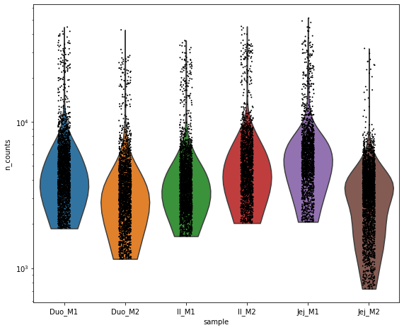

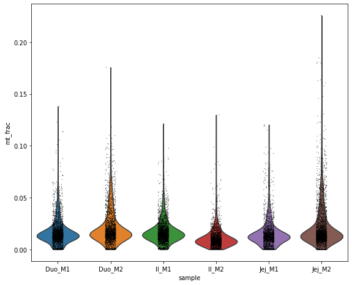

```python
# Quality control - plot QC metrics
#Sample quality plots
t1 = sc.pl.violin(adata, 'n_counts', groupby='sample', size=2, log=True, cut=0)
t2 = sc.pl.violin(adata, 'mt_frac', groupby='sample')
```

- 'Jej_M2'의 퀄리티가 좋지 않다
  - 세포 당 count가 낮다
  - 미토콘드리아 fraction이 높은 농도에서도 관측된다
- 이를 해결하기 위해 QC filltering을 수행한다.

### Visualization to conform threshold

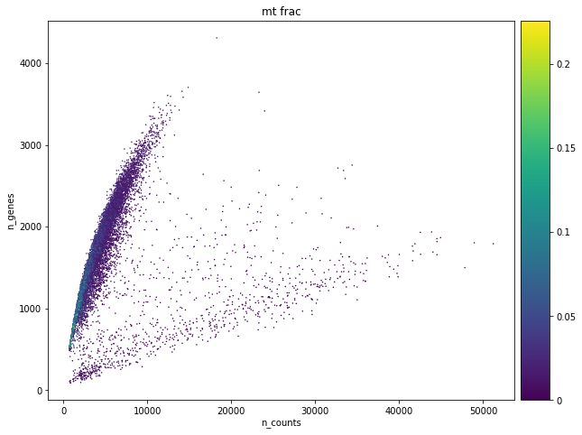

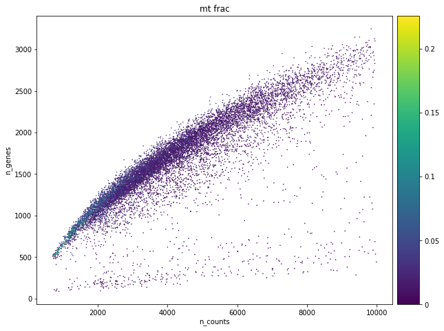

```python
#Data quality summary plots
p1 = sc.pl.scatter(adata, 'n_counts', 'n_genes', color='mt_frac')
p2 = sc.pl.scatter(adata[adata.obs['n_counts']<10000], 'n_counts', 'n_genes', color='mt_frac')
```

- 위의 그래프는 유전자-미토콘드리아 fraction의 수를 비교한 것이다.
- 첫번째 그래프에서는 유전자,세포 수, 미토콘드리아 fraction 관계를 보여준다.
- 두번째 그래프는 세포 수 10000 이하의 세포들을 보여준다.
- 급격하게 그래프 분포가 변화하기 때문에 QC과정에서 영역을 잘 나눠야 한다는 것을 알 수 있다.

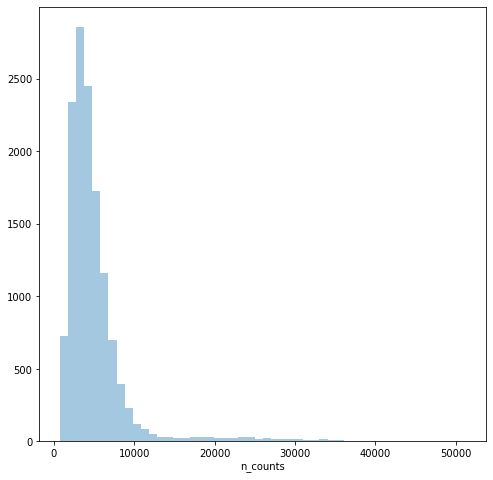

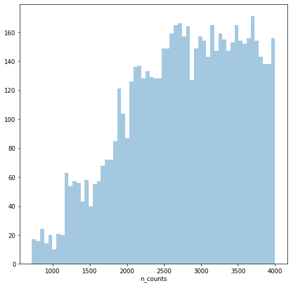

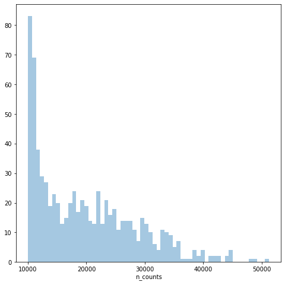

```python
#Thresholding decision: counts
p3 = sb.distplot(adata.obs['n_counts'], kde=False)
plt.show()

p4 = sb.distplot(adata.obs['n_counts'][adata.obs['n_counts']<4000], kde=False, bins=60)
plt.show()

p5 = sb.distplot(adata.obs['n_counts'][adata.obs['n_counts']>10000], kde=False, bins=60)
plt.show()
```

- Cell counts 1500 이하에서 보이는 두 개의 피크는 droplet의 세포잔해일 수 있다.
- Cell counts는 50000까지도 관측된다.
- Cell counts가 20000 이하부터 점진적으로 하락하는 것이 관측된다.

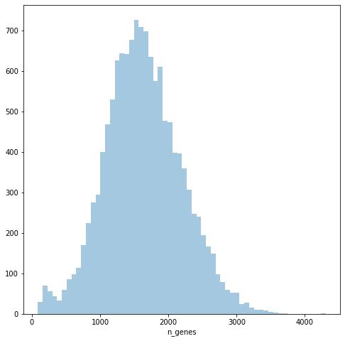

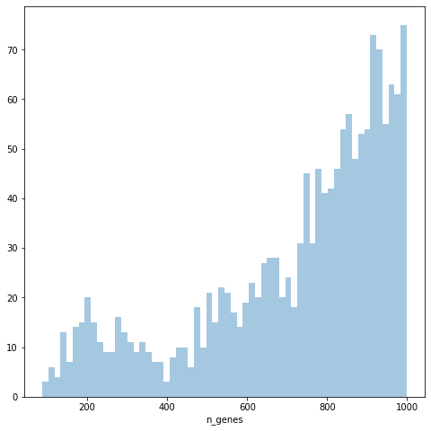

```python
#Thresholding decision: genes
p6 = sb.distplot(adata.obs['n_genes'], kde=False, bins=60)
plt.show()

p7 = sb.distplot(adata.obs['n_genes'][adata.obs['n_genes']<1000], kde=False, bins=60)
plt.show()
```

- 그래프를 본 결과 gene count 700 이하인 세포를 제거하는 것이 유의미해 보인다.
- 생물학적으로 이 이하는 죽은 세포 혹은 빈 droplet일 가능성이 있다.

### Filtering

```python
# Filter cells according to identified QC thresholds:
print('Total number of cells: {:d}'.format(adata.n_obs))

sc.pp.filter_cells(adata, min_counts = 1500)
print('Number of cells after min count filter: {:d}'.format(adata.n_obs))

sc.pp.filter_cells(adata, max_counts = 40000)
print('Number of cells after max count filter: {:d}'.format(adata.n_obs))

adata = adata[adata.obs['mt_frac'] < 20]
print('Number of cells after MT filter: {:d}'.format(adata.n_obs))

sc.pp.filter_cells(adata, min_genes = 700)
print('Number of cells after gene filter: {:d}'.format(adata.n_obs))
```

```
Total number of cells: 13353
filtered out 479 cells that have less than 1500 counts
```

```
Number of cells after min count filter: 12874
filtered out 16 cells that have more than 40000 counts
Number of cells after max count filter: 12858
Number of cells after MT filter: 12858
```

```
filtered out 401 cells that have less than 700 genes expressed
```

```
Trying to set attribute `.obs` of view, copying.
```

```
Number of cells after gene filter: 12457
```

```python
#Filter genes:
print('Total number of genes: {:d}'.format(adata.n_vars))

# Min 20 cells - filters out 0 count genes
sc.pp.filter_genes(adata, min_cells=20)
print('Number of genes after cell filter: {:d}'.format(adata.n_vars))
```

```
Total number of genes: 27998
filtered out 15180 genes that are detected in less than 20 cells
Number of genes after cell filter: 12818
```

- 그래프를 통해 정한 기준값에 따라 데이터들을 필터링한다.

### 2.2 Normalization

- 세포 각각의 서로 다른 수의 분자들을 갖고 있을 수 있다.
- 따라서 측정된 count를 정규화하기 위해 size factor를 계산하고 이용한다.
- Size factor는 세포 사이의 상대적인 비교를 가능하게 한다.
- Normalization의 방법으로는 differential testing, batch corection이 주로 사용된다.
- 이 방법을 사용하기 위해서는 먼저 coarse clustering을 수행하여 size factor 계산의 결과를 향상시켜야 한다.

```python
#Perform a clustering for scran normalization in clusters
adata_pp = adata.copy()
sc.pp.normalize_per_cell(adata_pp, counts_per_cell_after=1e6)
sc.pp.log1p(adata_pp)
sc.pp.pca(adata_pp, n_comps=15)
sc.pp.neighbors(adata_pp)
sc.tl.louvain(adata_pp, key_added='groups', resolution=0.5)
```

```
normalizing by total count per cell
    finished (0:00:00): normalized adata.X and added    'n_counts', counts per cell before normalization (adata.obs)
computing PCA
    with n_comps=15
    finished (0:00:12)
computing neighbors
    using 'X_pca' with n_pcs = 15
    finished: added to `.uns['neighbors']`
    `.obsp['distances']`, distances for each pair of neighbors
    `.obsp['connectivities']`, weighted adjacency matrix (0:00:29)
running Louvain clustering
    using the "louvain" package of Traag (2017)
    finished: found 10 clusters and added
    'groups', the cluster labels (adata.obs, categorical) (0:00:04)
```

```python
#Preprocess variables for scran normalization
input_groups = adata_pp.obs['groups']
data_mat = adata.X.T
```

[output not shown]

```python
%%R -i data_mat -i input_groups -o size_factors

size_factors = calculateSumFactors(data_mat, clusters=input_groups, min.mean=0.1)
```

```python
#Delete adata_pp
del adata_pp
```

```python
# Visualize the estimated size factors
adata.obs['size_factors'] = size_factors

sc.pl.scatter(adata, 'size_factors', 'n_counts')
sc.pl.scatter(adata, 'size_factors', 'n_genes')

sb.distplot(size_factors, bins=50, kde=False)
plt.show()
```

[output not shown]

```python
#Keep the count data in a counts layer
adata.layers["counts"] = adata.X.copy()
```

- Normalization 이전에 raw count data의 복사본을 만들어 저장한다.

```python
#Normalize adata
adata.X /= adata.obs['size_factors'].values[:,None]
sc.pp.log1p(adata)
```

```python
# Store the full data set in 'raw' as log-normalised data for statistical testing
adata.raw = adata
```

### 2.3 Batch Correction

- 서로 다른 샘플들 사이에서 battach effect가 발생하기 때문에 이를 제거하기 위한 batch correction을 수행한다.
- 장기에서 서로 다른 부위에서 얻은 세포정보이기 때문에 batch effect도 그 부위에 따라 다르게 나타난다.
- 이에 대한 batch correction은 세포의 분화과정에 대한 추적을 도와주기도 하지만, 이번 연습에서는 분화과정을 신경쓰지 않고 batch correction을 진행한다.

```python
# ComBat batch correction
sc.pp.combat(adata, key='sample')
```

- Combat batch correction의 경우 발현값이 음수로 나올 수 있다.
- 음수의 발현값은 강제로 0으로 수정하는 방식으로 고칠 수 있다.

### 2.4 Highly Variable Genes

- High Variable Genes(HVGs)만 뽑아내면 분석에 사용되는 데이터셋의 차원을 줄이고 주요한 정보들만 남길 수 있다.
- 데이터 내에서 biological variation과 깊게 연관된 gene만 선택한다.
- 이러한 유전자를 고르는 방법으로는 10x Genomics에서 배포하는 CellRanger를 사용하는 방법이 있다.
- 1000에서 5000개의 유전자가 보통 선택되게 된다.
- 이번 연습에서는 4000개의 유전자만 선택하기로 한다.

```python
sc.pp.highly_variable_genes(adata, flavor='cell_ranger', n_top_genes=4000)
print('\n','Number of highly variable genes: {:d}'.format(np.sum(adata.var['highly_variable'])))
```

```python
sc.pl.highly_variable_genes(adata)
```

[output not shown]

### 2.5 Visualization

- scRNA-seq 데이터의 시각화를 통해 필요한 정보를 알아내자.
- t-SNE visualization이 유명하다.
- UMAP algorithm을 통한 시각화도 유명하며 특히 데이터의 위상을 파악하는데 도움이 된다.

```python
# Calculate the visualizations
sc.pp.pca(adata, n_comps=50, use_highly_variable=True, svd_solver='arpack')
sc.pp.neighbors(adata)

sc.tl.tsne(adata, n_jobs=12) #Note n_jobs works for MulticoreTSNE, but not regular implementation)
sc.tl.umap(adata)
sc.tl.diffmap(adata)
sc.tl.draw_graph(adata)
```

### 2.6 Cell Cycle Scoring

- Reference를 기반으로 cell cycle(세포주기) effect의 점수를 매긴다.
- 점수에 따라 세포들을 주기에 따라 구분한다.

```python
#Score cell cycle and visualize the effect:
cc_genes = pd.read_table(cc_genes_file, delimiter='\t')
s_genes = cc_genes['S'].dropna()
g2m_genes = cc_genes['G2.M'].dropna()

s_genes_mm = [gene.lower().capitalize() for gene in s_genes]
g2m_genes_mm = [gene.lower().capitalize() for gene in g2m_genes]

s_genes_mm_ens = adata.var_names[np.in1d(adata.var_names, s_genes_mm)]
g2m_genes_mm_ens = adata.var_names[np.in1d(adata.var_names, g2m_genes_mm)]

sc.tl.score_genes_cell_cycle(adata, s_genes=s_genes_mm_ens, g2m_genes=g2m_genes_mm_ens)
```

```python
#Visualize the cell cycle
sc.pl.umap(adata, color=['S_score', 'G2M_score'], use_raw=False)
sc.pl.umap(adata, color='phase', use_raw=False)
```

[output not shown]

## 3 Downstream analysis

### 3.1 Clustering

- Clustering은 scRNA-seq 분석의 핵심이다.
- 세포는 그 종류(type)와 상태(state)로 구분할 수 있다.
- 이를 구분하기 위한 첫 단계가 clustering이다.
- Clustering의 방법으로는 k-nearest-neighbour grap에 따라 modularity optimization을 수행하는 것이 대표적이다.
- Clustering에 앞서서 resolution을 두 단계로 미리 나눌 것이다.
- 서로 다른 resolution을 분석함으로서 main cluster에 나타나는 clustering을 정확하게 알아낼 수 있다.
- Clustering은 HVGs에서 수행될 것이다.
- Dimensionality는 PCA에 의해서 수정될 것이다.
- 그래프는 KNN graph로 표현할 것이다.

```python
# Perform clustering - using highly variable genes
sc.tl.louvain(adata, key_added='louvain_r1')
sc.tl.louvain(adata, resolution=0.5, key_added='louvain_r0.5', random_state=10)
```

```python
adata.obs['louvain_r0.5'].value_counts()
```

```python
#Visualize the clustering and how this is reflected by different technical covariates
sc.pl.umap(adata, color=['louvain_r1', 'louvain_r0.5'], palette=sc.pl.palettes.default_64)
sc.pl.umap(adata, color=['region', 'n_counts'])
sc.pl.umap(adata, color=['log_counts', 'mt_frac'])
```

[output not shown]